# CMP.0005.00.02 - Técnicas Estatísticas de Predição - Avaliação Final

Diego Leonardo Urban

[output not shown]

# Cenário

Este documento contém a análise dos dados de um levantamento feito com 1289 pessoas dos Estados Unidos da América.

Os dados estão organizados com as seguintes variáveis:

| Rótulo | O que mede |
| --- | --- |
| obs | Rótulo das Observações. |
| salario | Salário dos indivíduos entrevistados – em milhares de reais por ano. |
| sexo | Se for do sexo feminino recebe valor 1, se for do seco masculino recebe valor 0. |
| cor | Recebe 1 se a pessoa for não-branca, 0 caso contrário. |
| est_civil | Recebe 1 caso a pessoa for casada, 0 caso contrário. |
| instrucao | Anos de educação formal que a pessoa recebeu. |
| experiencia | Anos de experiência que a possui na área em que trabalha. |
| idade | Anos de vida que a pessoa entrevistada possui. |

## Questão 1

Calcule as medidas de posição (Média, Mediana, Máximo, Mínimo, 1o Quartil e 3o quartil) para as variáveis “salario”, “instrucao”, “experiência” e “idade”. Apresente os cálculos e faça uma interpretação dos resultados.

### Salário

```
   Min. 1st Qu.  Median    Mean 3rd Qu.    Max.
   0.84    6.92   10.08   12.37   15.63   64.08
```

### Instrução

```
   Min. 1st Qu.  Median    Mean 3rd Qu.    Max.
   0.00   12.00   12.00   13.15   16.00   20.00
```

### Experiência

```
   Min. 1st Qu.  Median    Mean 3rd Qu.    Max.
   0.00    9.00   18.00   18.79   27.00   56.00
```

### Idade

```
   Min. 1st Qu.  Median    Mean 3rd Qu.    Max.
  18.00   29.00   37.00   37.93   47.00   65.00
```

Há pessoas sem instrução e com no máximo 20 anos de instrução. Média e Mediana entre 12 e 13 anos.

Há pessoas sem experiência e com no máximo 56 anos de experiência. Média e Mediana entre 18 e 19 anos. Aparenta ter assimetria a direita.

Com idade mínima de 18 e máxima de 65 anos. Média e Mediana entre 37 e 38 anos. Aparenta ser uma distribuição normal.

## Questão 2

Calcule as medidas de dispersão (Amplitude, Desvio-Padrão, Variância, Coeficiente de Variação, Assimetria e Curtose) para as variáveis “salario”, “instrucao”, “experiência” e “idade”.

### Salário

```
Amplitude =  63.24
Desvio Padrão =  7.89635
Variância =  62.35235
Coeficiente de Variação =  0.6385611
Assimetria =  1.845964
Curtose =  4.824411
```

### Instrução

```
Amplitude =  20
Desvio Padrão =  2.813823
Variância =  7.917602
Coeficiente de Variação =  0.2140592
Assimetria =  -0.2900436
Curtose =  2.968193
```

### Experiência

```
Amplitude =  56
Desvio Padrão =  11.66284
Variância =  136.0218
Coeficiente de Variação =  0.6207018
Assimetria =  0.3752323
Curtose =  -0.675665
```

### Idade

```
Amplitude =  47
Desvio Padrão =  11.49428
Variância =  132.1184
Coeficiente de Variação =  0.3030006
Assimetria =  0.2692705
Curtose =  -0.772023
```

#### Com relação ao Coeficiente de Variação, qual é a variável que possui maior discrepância em seus valores? E a com menor discrepância?

A variável Instrução possui menor discrepância com 0.2140592 enquanto que a variável de maior discrepância é o Salário com 0.6385611.

#### Qual deve ser a interpretação dada ao Coeficiente de Variação?

Quanto menor o Coeficiente de Variação mais homogêneo é o conjunto de dados.

#### Considerando que as medidas de Assimetria e Curtose qualificam a média como boa medida de tendência central, existe alguma das variáveis que possua problemas de assimetria e/ou curtose? Justifique.

As variáveis Experiência e Idade aparentam ter medidas de assimetria e curtose mais leves enquanto que o Salário e Instrução aparentam serem mais acentuadas.

## Questão 3

Considere uma análise que possa ser realizada sobre a variável salario. Faça os procedimentos destacados a seguir:

### Calcule a média e a mediana do “salario” para mulheres e homens separadamente. Qual é a tendência apresentada para média e para mediana?

```
Média do Salário dos Homens =  14.11889
Mediana do Salário dos Homens =  12

Média do Salário das Mulheres =  10.59367
Mediana do Salário das Mulheres =  8.89
```

Há uma tendência de homens ganharem mais do que mulheres.

### Calcule a média do “salario” para brancos e não brancos. Qual é a tendência apresentada para média e para mediana?

```
Média do Salário de Brancos =  12.79442
Mediana do Salário de Brancos =  11

Média do Salário de Não Brancos =  9.990203
Mediana do Salário de Não Brancos =  8
```

Há uma tendência de pessoas Brancas em média, ganharem mais do que pessoas Não Brancas.

## Questão 4

Faça um gráfico Box-Plot para as variáveis salario, instrucao, experiencia e idade e identifique se existem outliers. Quantas observações deveriam ser excluídas em cada variável por serem prováveis outliers?

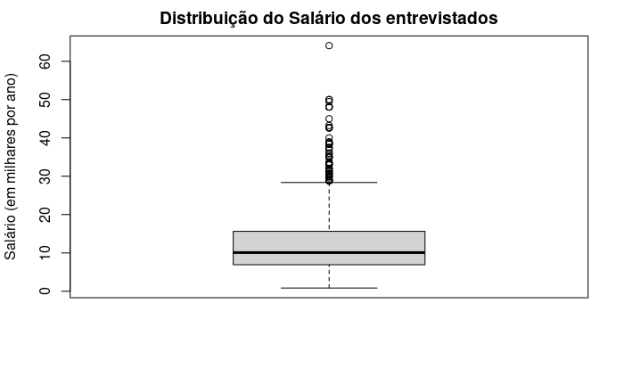

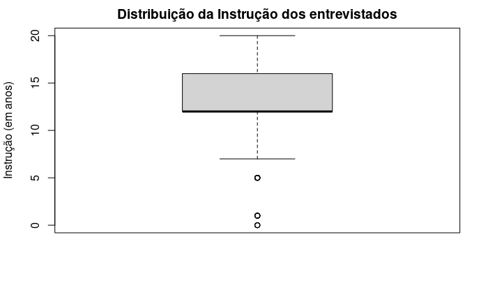

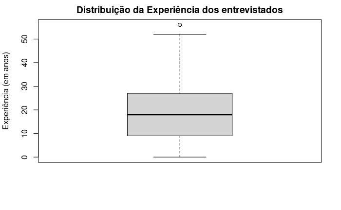

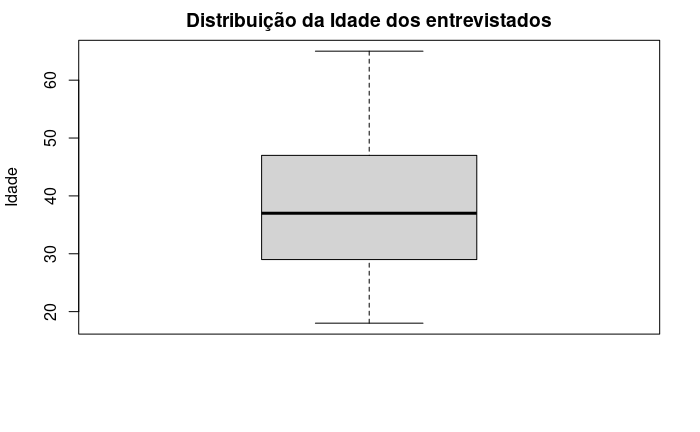

## Questão 5

Considerando os gráficos de dispersão, construa-os conforme pedido a seguir:

### Faça um gráfico que relacione o “salario” com o tempo de “instrucao”. Analise uma eventual tendência dos dados.

[figure not shown]

Há uma tendência de que quanto mais anos de instrução o entrevistado tem, maior é o seu salário.

### Faça um gráfico que relacione o “salario” com o tempo de “experiência”. Analise uma eventual tendência dos dados.

[figure not shown]

Há uma leve tendência de que quanto mais anos de experiência o entrevistado tem, maior é o seu salário.

### Faça um gráfico que relacione o “salario” com a “idade”. Analise uma eventual tendência dos dados.

[figure not shown]

Há uma leve tendência de que quanto maior a indade do entrevistado, maior é o seu salário.

### Faça um gráfico que relacione a “experiencia” com o tempo de “instrucao”. Analise uma eventual tendência dos dados.

[figure not shown]

Há uma tendência de que entrevistados com mais anos de experiência tem menos anos de instrução.

## Questão 6

Considerando as variáveis estritamente quantitativas. Construa um Histograma e identifique a variável com melhor ajuste percebido para a distribuição normal de probabilidade.

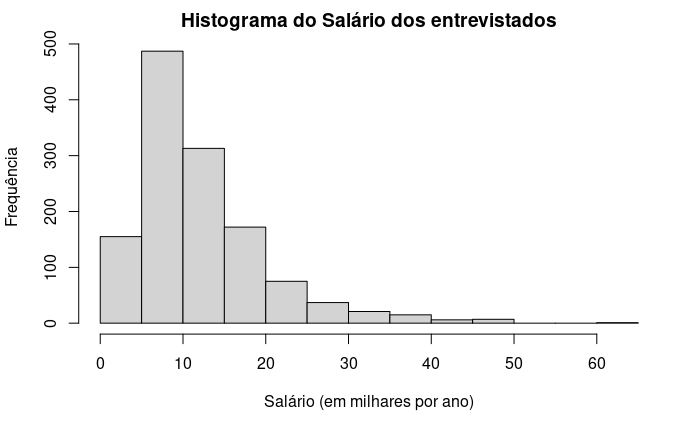

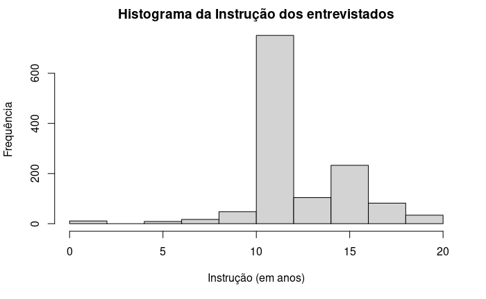

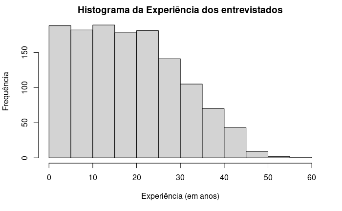

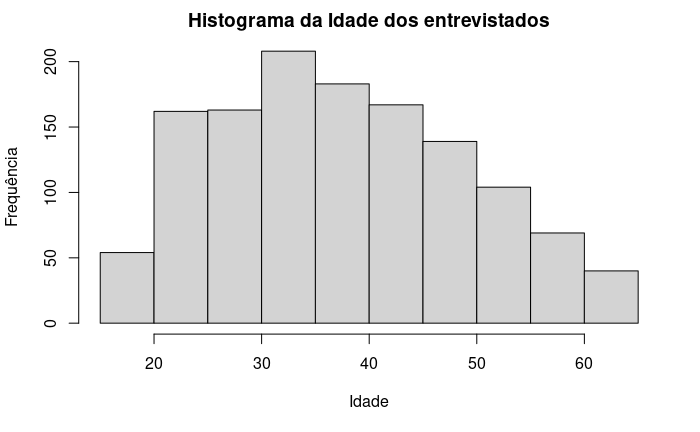

A variável Idade aparenta ser a variável com melhor ajuste para a distribuição normal.